# macro_rotation

## Macro Factor Rotation Tracker

## How Fed rate decisions, CPI prints, GDP releases and yield curve shifts drive S&P 500 sector rotation

**Author:** Prem Mehta | MSc Data Analytics, Dublin City University  
**Data sources:** FRED API (macro), yFinance (sector ETFs)  
**Period:** 2024–2026

**Research question:** When macroeconomic conditions shift — rising fed rates, elevated inflation, yield curve inversion — how do capital flows rotate across equity sectors, and with what lag?

**Key insight:** Sector ETFs (XLE, XLF, XLK etc.) act as proxies for capital allocation decisions by institutional investors. By mapping discrete macro events to subsequent sector returns at T+1, T+5, and T+20 trading days, we can quantify which sectors benefit or suffer from each type of macro shock.

```
macro_full:    (730, 21)
macro_events:  (57, 5)
event_returns: (540, 9)
regime_daily:  (5010, 17)

Macro columns: ['date', 'yield_curve', 'VIX', 'CPI_US', 'DXY_FRED', 'Gold_USD', 'WTI_Oil', 'USD_INR', 'DXY', 'fed_funds_rate', 'gdp_growth_qoq', 'nonfarm_payrolls', 'unemployment_rate', 'treasury_10y', 'treasury_2y', 'yield_spread_10y2y', 'fed_rate_chg', 'rate_regime', 'cpi_yoy', 'inflation_regime',…
```

## 1. Macro Timeline

Visualising Fed Funds Rate, CPI, yield curve spread, VIX and DXY together — with macro event markers overlaid. This establishes the macro environment context for the entire analysis.

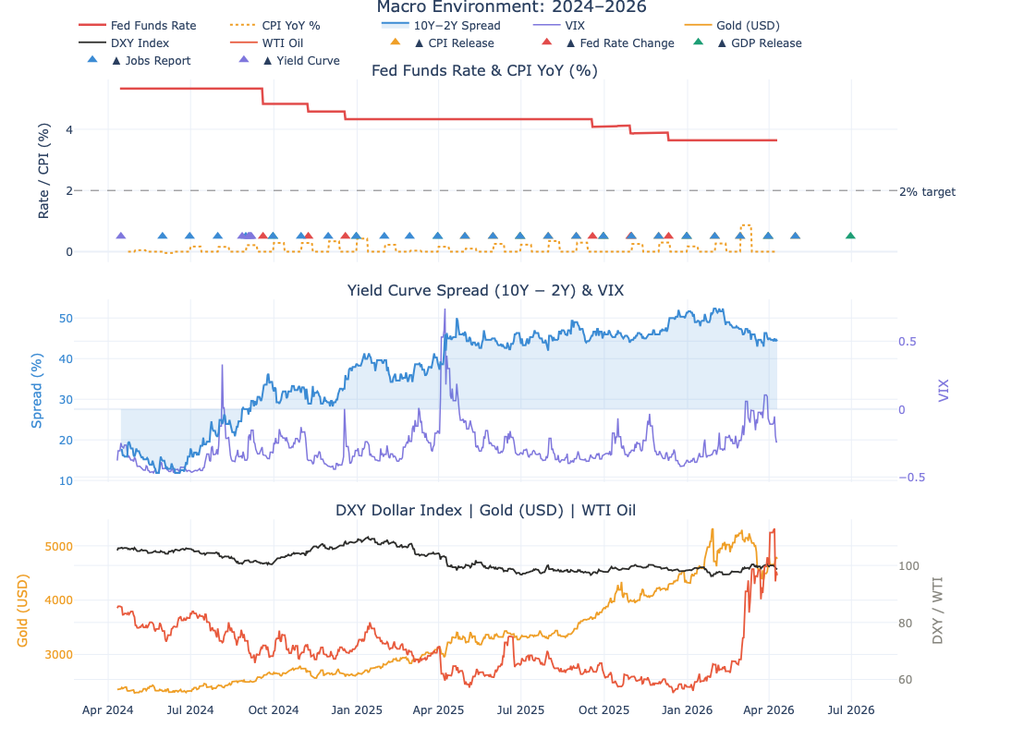

## 2. Sector Heatmap — Returns After Macro Events

For each macro event type, we compute the average sector ETF return over three windows:

- **T+1** — next trading day (immediate reaction)
- **T+5** — one week (short-term repricing)
- **T+20** — one month (sustained rotation)

Green = sector outperformed after this event type. Red = underperformed. The pattern reveals which sectors act as macro shock absorbers and which are most sensitive.

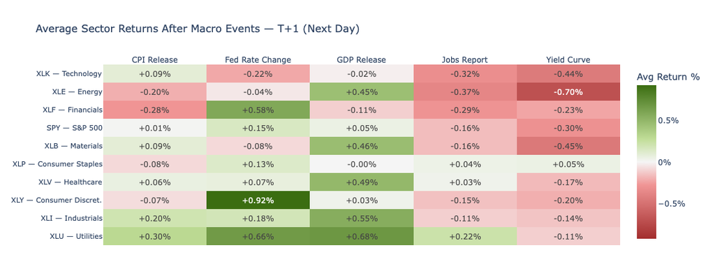

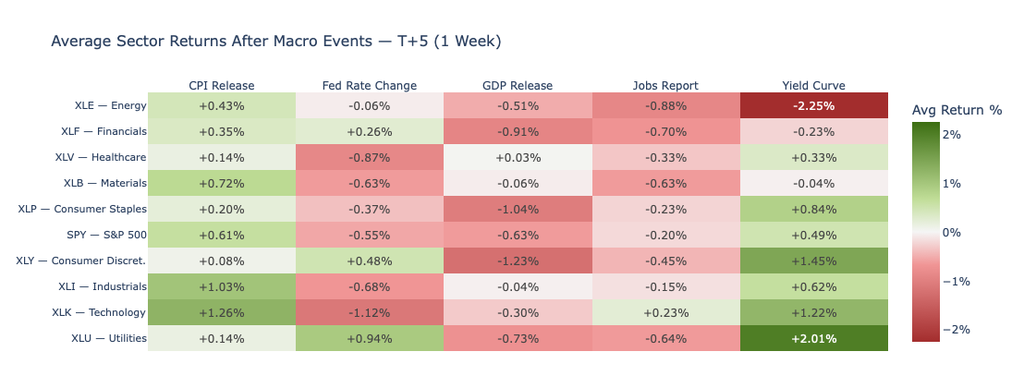

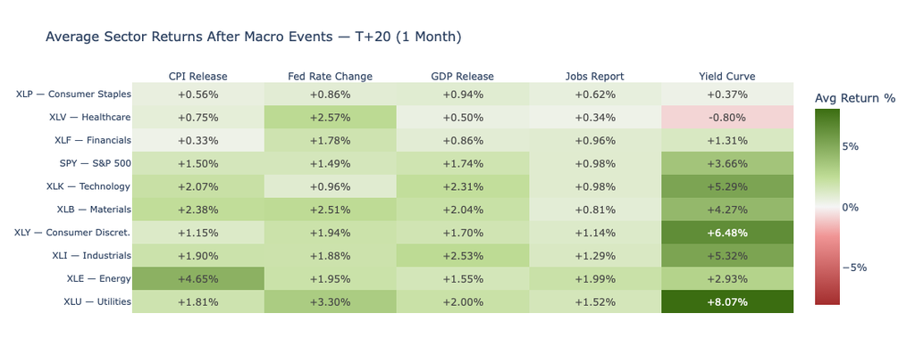

## 3. Regime Analysis — Sector Performance by Rate Environment

We tag every trading day as **Hiking**, **Cutting**, or **Hold** based on Fed Funds Rate changes, then compare average daily sector returns across regimes.

**Expected pattern:**

- Hiking cycles → Financials (XLF) benefit from wider margins; Technology (XLK) suffers from higher discount rates
- Cutting cycles → Growth sectors (XLK, XLY) re-rate upward; Utilities (XLU) and Staples (XLP) underperform as risk appetite returns
- Inverted yield curve → Defensive sectors (XLV, XLU, XLP) typically outperform

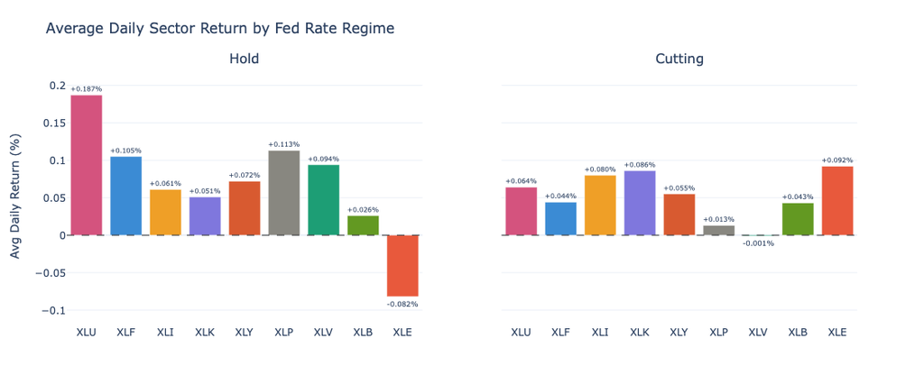

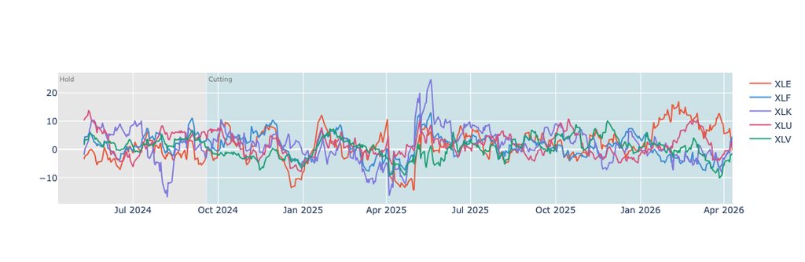

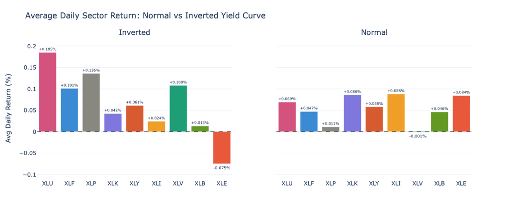